# (Exploring Udemy Courses Data ) by (Omar Waheed)

## Preliminary Wrangling

> This data set is sample of udemy courses data set gathered by using udemy devolper api and is made of 3682 row and 23 column this data collected at the beginning of 2020 and consist of some important course information mentioned below .

| column name | usage |
| --- | --- |
| title | course name on the site |
| avg_rating | course rate |
| current_price | current course price |
| num_subscribers | number of course subscribers |
| num_reviews | number of reviews for the course |
| num_lectures | number of course lectures |
| primary_category | the main category that this course belong to |
| primary_subcategory | the sub category that this course belong to |
| course_creation_date | date of creation |
| course_level | the level of knowledge this course belongs to |

### Importing Libraries needed

```python
# import all packages and set plots to be embedded inline
import numpy as np
import pandas as pd
import matplotlib.pyplot as plt
import seaborn as sb
%matplotlib inline
base_color = sb.color_palette()[0]
import warnings
warnings.simplefilter("ignore")
```

> Loading dataset and describe its properties through the questions below.

### Gathering and assessing data

```python
df = pd.read_csv('MyUdemyCoursesData.csv')
df.head().T
```

|  | 0 | 1 | 2 | 3 | 4 |
| --- | --- | --- | --- | --- | --- |
| title | Deep Learning : Computer Vision Beginner to Ad... | Machine Learning and Data Science Hands-on wit... | Machine Learning (ML) Bootcamp: Python, Tensor... | Learn to Code with Python 3! | Mastering Visual Studio Code |
| url | https://www.udemy.com/course/deep-learning-pyt... | https://www.udemy.com/course/machine-learning-... | https://www.udemy.com/course/ml-bootcamp/ | https://www.udemy.com/course/python3-for-begin... | https://www.udemy.com/course/mastering-visual-... |
| id | 2494264 | 1978034 | 2229568 | 2371066 | 2664746 |
| avg_rating | 4.39286 | 3.72727 | 4.4375 | 4.11301 | 4.25806 |
| price | 199.99 | 199.99 | 189.99 | 199.99 | 49.99 |
| current_price | 11.99 | 11.99 | 11.99 | 11.99 | 11.99 |
| headline | Go Beginner to Pro in Computer Vision in Pytor... | Machine Learning, Statistics, Python, AI, Tens... | Master the 3 M's of ML: Maths, Methods and Mac... | Go from beginner to advanced with the Python p... | Boost your productivity by using the best IDE ... |
| num_subscribers | 7758 | 46560 | 6860 | 92051 | 3119 |
| num_reviews | 85 | 1103 | 8 | 1191 | 31 |
| num_lectures | 74 | 522 | 48 | 78 | 66 |
| primary_category | development | development | development | development | development |
| primary_category_link | https://www.udemy.com/courses/development/ | https://www.udemy.com/courses/development/ | https://www.udemy.com/courses/development/ | https://www.udemy.com/courses/development/ | https://www.udemy.com/courses/development/ |
| primary_subcategory | data-science | data-science | data-science | programming-languages | other-it-and-software |
| primary_subcategory_link | https://www.udemy.com/courses/development/data... | https://www.udemy.com/courses/development/data... | https://www.udemy.com/courses/development/data... | https://www.udemy.com/courses/development/prog... | https://www.udemy.com/courses/development/othe... |
| course_creation_date | 2019-08-05T03:56:57Z | 2018-10-20T07:06:41Z | 2019-02-19T19:41:12Z | 2019-05-16T20:52:02Z | 2019-11-20T14:57:47Z |
| instructor_name | Manifold AI Learning ® | EDU CBA | Samuel Reischl | Joseph Delgadillo | Alex Horea |
| instructor_Link | https://www.udemy.com/user/manifold-ai-learning/ | https://www.udemy.com/user/premananda-suna/ | https://www.udemy.com/user/samuel-reischl/ | https://www.udemy.com/user/josephdelgadillo2/ | https://www.udemy.com/user/alexhorea/ |
| what_you_will_learn | ['Master how to Perform Computer Vision Task w... | ['Learn the use of Python for Data Science and... | ['The three building blocks of Machine Learnin... | ['Introduction to Python and Setup', 'Python P... | ['Install and configure VSCode', 'Handle Exten... |
| description_non_formatted | <p>With the <strong>Deep learning</strong> mak... | <p>Learn from well designed, well-crafted stud... | <p>Do you want to <strong>master Machine Learn... | <p>If you would like to learn <strong>Python 3... | <p><strong>Visual Studio Code</strong> is the ... |
| reviews | [[5.0, 'good course with neat explanations'], ... | [[5.0, 'the teaching is very good and they giv... | [[4.0, 'El contenido ha sido claro en el proce... | [[4.0, 'yes'], [3.5, 'the recording is kind of... | [[5.0, 'Vscode has so many features and it’s e... |
| course_level | All Levels | All Levels | All Levels | All Levels | Intermediate Level |
| small_image_link | https://i.udemycdn.com/course/96x54/2494264_9a... | https://i.udemycdn.com/course/96x54/1978034_1c... | https://i.udemycdn.com/course/96x54/2229568_3a... | https://i.udemycdn.com/course/96x54/2371066_74... | https://i.udemycdn.com/course/96x54/2664746_b9... |
| medium_image | https://i.udemycdn.com/course/125_H/2494264_9a... | https://i.udemycdn.com/course/125_H/1978034_1c... | https://i.udemycdn.com/course/125_H/2229568_3a... | https://i.udemycdn.com/course/125_H/2371066_74... | https://i.udemycdn.com/course/125_H/2664746_b9... |

```python
# Let's see some info about columns
df.info()
```

```
<class 'pandas.core.frame.DataFrame'>
RangeIndex: 3682 entries, 0 to 3681
Data columns (total 23 columns):
 #   Column                     Non-Null Count  Dtype
---  ------                     --------------  -----
 0   title                      3682 non-null   object
 1   url                        3682 non-null   object
 2   id                         3682 non-null   int64
 3   avg_rating                 3682 non-null   float64
 4   price                      3682 non-null   float64
 5   current_price              3682 non-null   float64
 6   headline                   3681 non-null   object
 7   num_subscribers            3682 non-null   int64
 8   num_reviews                3682 non-null   int64
 9   num_lectures               3682 non-null   int64
 10  primary_category           3679 non-null   object
 11  primary_category_link      3679 non-null   object
 12  primary_subcategory        3679 non-null   object
 13  primary_subcategory_link   3679 non-null   object
 14  course_creation_date       3682 non-null   object
 15  instructor_name            3681 non-null   object
 16  instructor_Link            3681 non-null   object
 17  what_you_will_learn        3682 non-null   object
 18  description_non_formatted  3681 non-null   object
 19  reviews                    3682 non-null   object
 20  course_level               3682 non-null   object
 21  small_image_link           3682 non-null   object
 22  medium_image               3682 non-null   object
dtypes: float64(3), int64(4), object(16)
memory usage: 661.7+ KB
```

```python
# View Data Statistics
df.describe()
```

|  | id | avg_rating | price | current_price | num_subscribers | num_reviews | num_lectures |
| --- | --- | --- | --- | --- | --- | --- | --- |
| count | 3.682000e+03 | 3682.000000 | 3682.000000 | 3682.000000 | 3.682000e+03 | 3682.000000 | 3682.000000 |
| mean | 1.762684e+06 | 4.005952 | 76.789120 | 9.540888 | 1.331627e+04 | 479.528789 | 46.287072 |
| std | 6.341303e+05 | 0.648234 | 78.836801 | 8.887308 | 3.305092e+04 | 2353.004081 | 59.634383 |
| min | 9.711000e+03 | 0.000000 | 0.000000 | 0.000000 | 1.100000e+02 | 0.000000 | 0.000000 |
| 25% | 1.396170e+06 | 3.800000 | 0.000000 | 0.000000 | 2.802250e+03 | 22.000000 | 16.000000 |
| 50% | 1.795006e+06 | 4.148400 | 34.990000 | 11.990000 | 5.819000e+03 | 68.000000 | 28.000000 |
| 75% | 2.298756e+06 | 4.375000 | 149.990000 | 11.990000 | 1.261800e+04 | 235.000000 | 52.000000 |
| max | 2.800386e+06 | 5.000000 | 199.990000 | 199.990000 | 1.244120e+06 | 76688.000000 | 670.000000 |

```python
#  now lets see duplicates in data
sum(df.duplicated())
```

```
0
```

```python
# lets see if there is null values
df.isnull().sum()
```

```
title                        0
url                          0
id                           0
avg_rating                   0
price                        0
current_price                0
headline                     1
num_subscribers              0
num_reviews                  0
num_lectures                 0
primary_category             3
primary_category_link        3
primary_subcategory          3
primary_subcategory_link     3
course_creation_date         0
instructor_name              1
instructor_Link              1
what_you_will_learn          0
description_non_formatted    1
reviews                      0
course_level                 0
small_image_link             0
medium_image                 0
dtype: int64
```

### Cleaning Data

#### Copying data frame

```python
courses_data = df.copy()
```

#### Removing unused coulmns :

- url , primary_category_link , primary_subcategory_link , instructor_name , instructor_Link ,what_you_will_learn ,description_non*formatted , reviews ,small* image_link , medium_image
- this coulmns contain extra information which is not necessery .*

```python
courses_data.drop(columns=['url', 'primary_category_link' , 'primary_subcategory_link' , 'instructor_name' , 'instructor_Link' ,'what_you_will_learn' ,'description_non_formatted' , 'reviews' ,'small_image_link' , 'medium_image'],inplace=True)
courses_data.info()
```

```
<class 'pandas.core.frame.DataFrame'>
RangeIndex: 3682 entries, 0 to 3681
Data columns (total 13 columns):
 #   Column                Non-Null Count  Dtype
---  ------                --------------  -----
 0   title                 3682 non-null   object
 1   id                    3682 non-null   int64
 2   avg_rating            3682 non-null   float64
 3   price                 3682 non-null   float64
 4   current_price         3682 non-null   float64
 5   headline              3681 non-null   object
 6   num_subscribers       3682 non-null   int64
 7   num_reviews           3682 non-null   int64
 8   num_lectures          3682 non-null   int64
 9   primary_category      3679 non-null   object
 10  primary_subcategory   3679 non-null   object
 11  course_creation_date  3682 non-null   object
 12  course_level          3682 non-null   object
dtypes: float64(3), int64(4), object(6)
memory usage: 374.1+ KB
```

#### Removing rows with nulls :

```python
courses_data.dropna(inplace=True)
# lets see if there is null values
courses_data.isnull().sum()
```

```
title                   0
id                      0
avg_rating              0
price                   0
current_price           0
headline                0
num_subscribers         0
num_reviews             0
num_lectures            0
primary_category        0
primary_subcategory     0
course_creation_date    0
course_level            0
dtype: int64
```

#### Make copy for visualization of time series

```python
time_series = courses_data.copy()
time_series["course_creation_date"]=  pd.to_datetime(time_series["course_creation_date"])
time_series.T
```

|  | 0 | 1 | 2 | 3 | 4 | 5 | 6 | 7 | 8 | 9 | ... | 3672 | 3673 | 3674 | 3675 | 3676 | 3677 | 3678 | 3679 | 3680 | 3681 |
| --- | --- | --- | --- | --- | --- | --- | --- | --- | --- | --- | --- | --- | --- | --- | --- | --- | --- | --- | --- | --- | --- |
| title | Deep Learning : Computer Vision Beginner to Ad... | Machine Learning and Data Science Hands-on wit... | Machine Learning (ML) Bootcamp: Python, Tensor... | Learn to Code with Python 3! | Mastering Visual Studio Code | Become a Resume/CV Master. Create The Best Res... | Machine Learning From First Principles | Creating GraphQL APIs with ASP.Net Core for Be... | The Art of Doing: Code 40 Challenging Python P... | Boost Your Testosterone and Sex Drive Naturally | ... | Learn to make a level editor in unity | A Sweet Bootcamp on Golang [Feb 2020] | RxJS 101 | Blender 2.8 Beginners Guide To 3D Modeling A S... | Digital Signal Processing with MATLAB Applicat... | Coding Interview Question : Data Structures & ... | Unity Game Dev for Beginners \| Build a 3D Ball... | C# .NET Database and XML Applications | Deep Learning with Google Colab | Learn Python with Google Colab - A Step to Mac... |
| id | 2494264 | 1978034 | 2229568 | 2371066 | 2664746 | 2787944 | 2543133 | 2758808 | 2666730 | 2271382 | ... | 2716252 | 2790842 | 2417262 | 2791410 | 2732534 | 2790502 | 2414834 | 2780742 | 2579724 | 2755278 |
| avg_rating | 4.39286 | 3.72727 | 4.4375 | 4.11301 | 4.25806 | 3.48 | 4.2 | 3.625 | 4.42949 | 3.95 | ... | 0 | 4.91667 | 4.06452 | 0 | 0 | 0 | 0 | 3.5 | 0 | 0 |
| price | 199.99 | 199.99 | 189.99 | 199.99 | 49.99 | 0 | 0 | 29.99 | 199.99 | 49.99 | ... | 0 | 24.99 | 0 | 184.99 | 0 | 199.99 | 0 | 0 | 19.99 | 0 |
| current_price | 11.99 | 11.99 | 11.99 | 11.99 | 11.99 | 0 | 0 | 11.99 | 18.99 | 11.99 | ... | 0 | 11.99 | 0 | 11.99 | 0 | 11.99 | 0 | 0 | 11.99 | 0 |
| headline | Go Beginner to Pro in Computer Vision in Pytor... | Machine Learning, Statistics, Python, AI, Tens... | Master the 3 M's of ML: Maths, Methods and Mac... | Go from beginner to advanced with the Python p... | Boost your productivity by using the best IDE ... | Personal Development: Create and Design A Prof... | Discussing the principles behind the most used... | Understood GraphQL specifications as well as u... | Computer Science Through Python Application | Become a superhuman by optimizing your endocri... | ... | How to make a level editor for PC's to be used... | Learn Golang from Scratch, Learn golang by pra... | Learn the basics of RxJS, and get up and runni... | Blender 2.8 A Beginners Complete Guide To Mode... | Digital signal processing with MATLAB applicat... | Ace your next C++ coding interview by masterin... | Understand the basic principles of game develo... | Implementing Real-World Examples | Implementing and training deep learning models... | Hands on course in python basics with Google C... |
| num_subscribers | 7758 | 46560 | 6860 | 92051 | 3119 | 3360 | 8445 | 2137 | 26700 | 2010 | ... | 1918 | 1096 | 3065 | 7426 | 1074 | 2119 | 4106 | 2113 | 2513 | 1762 |
| num_reviews | 85 | 1103 | 8 | 1191 | 31 | 25 | 5 | 4 | 157 | 61 | ... | 0 | 6 | 63 | 0 | 0 | 0 | 0 | 1 | 0 | 0 |
| num_lectures | 74 | 522 | 48 | 78 | 66 | 16 | 77 | 43 | 156 | 23 | ... | 12 | 98 | 54 | 68 | 14 | 36 | 31 | 15 | 61 | 25 |
| primary_category | development | development | development | development | development | personal-development | development | development | development | health-and-fitness | ... | development | development | development | design | teaching-and-academics | development | development | it-and-software | development | it-and-software |
| primary_subcategory | data-science | data-science | data-science | programming-languages | other-it-and-software | career-development | other-it-and-software | software-engineering | programming-languages | fitness | ... | game-development | programming-languages | web-development | 3d-and-animation | engineering | databases | game-development | it-certification | data-science | it-certification |
| course_creation_date | 2019-08-05 03:56:57+00:00 | 2018-10-20 07:06:41+00:00 | 2019-02-19 19:41:12+00:00 | 2019-05-16 20:52:02+00:00 | 2019-11-20 14:57:47+00:00 | 2020-01-30 17:36:55+00:00 | 2019-09-04 10:15:52+00:00 | 2020-01-14 15:13:01+00:00 | 2019-11-21 18:14:35+00:00 | 2019-03-14 13:37:41+00:00 | ... | 2019-12-21 21:51:39+00:00 | 2020-02-01 14:33:46+00:00 | 2019-06-17 12:23:19+00:00 | 2020-02-01 22:46:54+00:00 | 2020-01-01 20:19:48+00:00 | 2020-02-01 09:30:18+00:00 | 2019-06-15 12:27:48+00:00 | 2020-01-26 20:33:39+00:00 | 2019-09-27 09:25:14+00:00 | 2020-01-12 18:51:08+00:00 |
| course_level | All Levels | All Levels | All Levels | All Levels | Intermediate Level | Beginner Level | All Levels | All Levels | Beginner Level | All Levels | ... | Intermediate Level | All Levels | All Levels | Beginner Level | All Levels | All Levels | Beginner Level | Intermediate Level | Intermediate Level | Beginner Level |

13 rows × 3678 columns

#### Add month and year columns

```python
time_series['year']= time_series.course_creation_date.dt.year
time_series['month'] = time_series.course_creation_date.dt.month
time_series.info()
```

```
<class 'pandas.core.frame.DataFrame'>
Int64Index: 3678 entries, 0 to 3681
Data columns (total 15 columns):
 #   Column                Non-Null Count  Dtype
---  ------                --------------  -----
 0   title                 3678 non-null   object
 1   id                    3678 non-null   int64
 2   avg_rating            3678 non-null   float64
 3   price                 3678 non-null   float64
 4   current_price         3678 non-null   float64
 5   headline              3678 non-null   object
 6   num_subscribers       3678 non-null   int64
 7   num_reviews           3678 non-null   int64
 8   num_lectures          3678 non-null   int64
 9   primary_category      3678 non-null   object
 10  primary_subcategory   3678 non-null   object
 11  course_creation_date  3678 non-null   datetime64[ns, UTC]
 12  course_level          3678 non-null   object
 13  year                  3678 non-null   int64
 14  month                 3678 non-null   int64
dtypes: datetime64[ns, UTC](1), float64(3), int64(6), object(5)
memory usage: 619.8+ KB
```

#### Add paid column

```python
# assign true to all rows
courses_data["paid"] = 'paid'
# assign false to courses with price 0
courses_data.loc[(courses_data.current_price == 0.0),'paid']="free"
courses_data.paid.value_counts()
```

```
paid    2741
free     937
Name: paid, dtype: int64
```

### What is/are the main feature(s) of interest in your dataset?

> The main features is price and rating of courses and subcategory of each course and level of each course

### What features in the dataset do you think will help support your investigation into your feature(s) of interest?

> average rating ,price ,num_subscribers,num_reviews,course level

## Univariate Exploration

> Let's check the important variables distribution

#### Checking distribution of paid and free courses

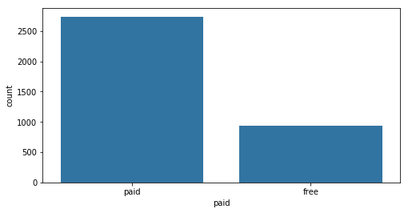

```python
sb.countplot( data=courses_data ,x='paid',color = base_color)
fig = plt.gcf()
fig.set_size_inches(8,4)
```

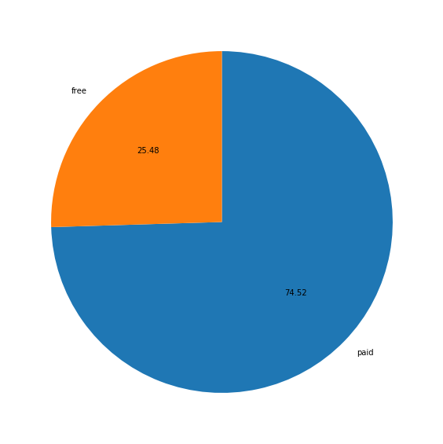

```python
sorted_counts = courses_data['paid'].value_counts()
plt.pie(sorted_counts, labels = sorted_counts.index, startangle = 90, counterclock = False,autopct='%1.2f');
fig = plt.gcf()
fig.set_size_inches(20, 10)
```

> we can notice that from this sample that free courses is only 25 % from the full distribution and the rest of courses is paid courses and present 75% of the distribution

#### checking absolute Counts of each level :

```python
Levels_count = courses_data['course_level'].value_counts()
Levels_order = Levels_count.index
```

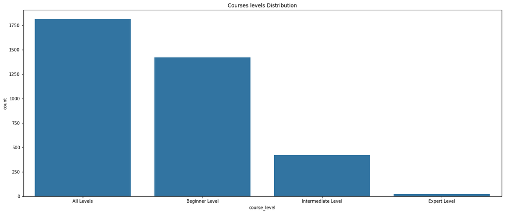

```python
plt.title('Courses levels Distribution')
plt.xlabel('Level')
plt.ylabel('courses Count')
fig = plt.gcf()
fig.set_size_inches(20,8)

sb.countplot(data = courses_data, x = 'course_level',order = Levels_order, color = base_color)
```

#### checking relative Counts of each level :

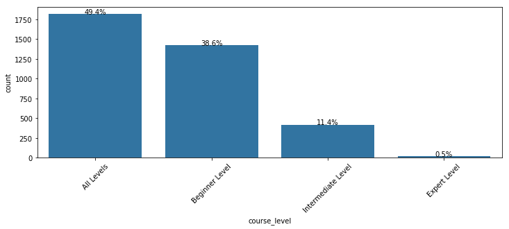

```python
sb.countplot(data=courses_data, x='course_level', color=base_color, order=Levels_order);
df_count = courses_data.shape[0]
# Recalculating the type_counts just to have clarity.
type_counts = courses_data['course_level'].value_counts()

# get the current tick locations and labels
locs, labels = plt.xticks(rotation=90)

# loop through each pair of locations and labels
for loc, label in zip(locs, labels):

    # get the text property for the label to get the correct count
    count = type_counts[label.get_text()]
    pct_string = '{:0.1f}%'.format(100*count/df_count)

    # print the annotation just below the top of the bar
    plt.text(loc, count+2, pct_string, ha = 'center', color = 'black')

plt.xticks(rotation=45)
fig = plt.gcf()
# Change seaborn plot size
fig.set_size_inches(12, 4)
```

> course level distribution clearly shows that courses that is for every one is more produced to gain more money and to get bigger number of subscribers and on the other hand beginner levelk courses comes in the second place with 38.6%

#### Checking current_price variable distribution

```python
courses_data.current_price.value_counts()
```

```
11.99     2373
0.00       937
12.99      269
13.99       30
19.99       18
18.99       13
34.99        8
24.99        4
49.99        4
199.99       4
14.99        3
29.99        3
39.99        2
69.99        2
17.99        2
47.99        1
43.99        1
25.99        1
64.99        1
94.99        1
59.99        1
Name: current_price, dtype: int64
```

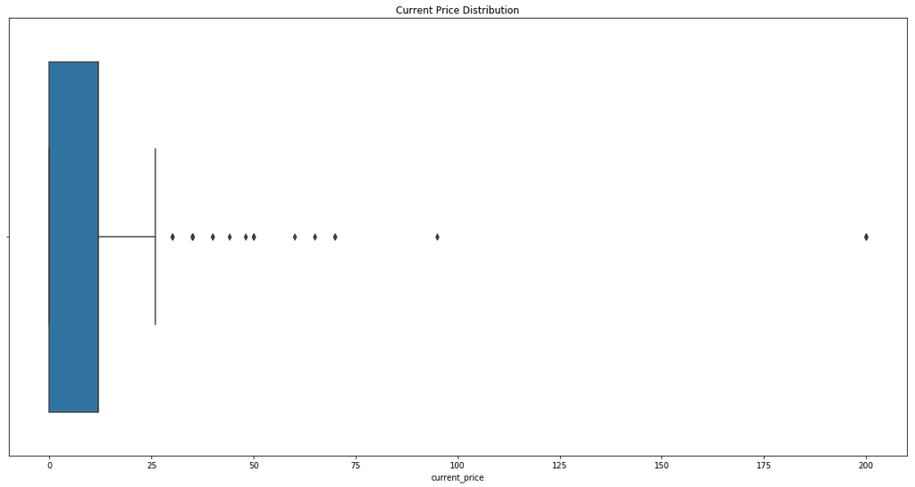

```python
plt.title('Current Price Distribution')
plt.xlabel('Price')
fig = plt.gcf()
fig.set_size_inches(20, 10)
sb.boxplot(data=courses_data ,x='current_price')
```

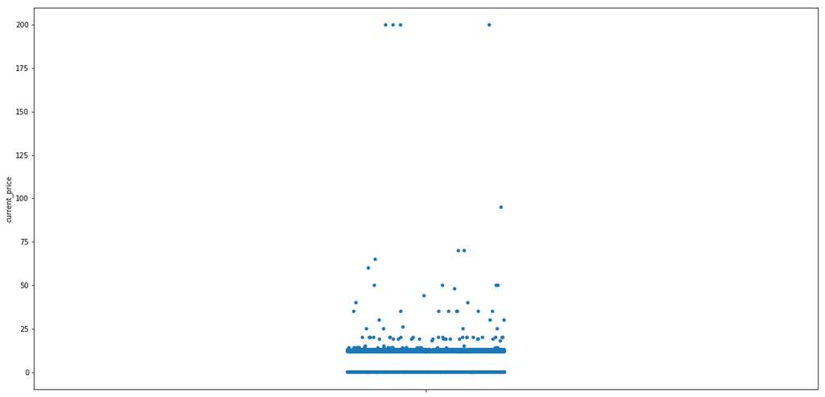

```python
sb.stripplot(y=courses_data['current_price'])
fig = plt.gcf()
fig.set_size_inches(20, 10)
```

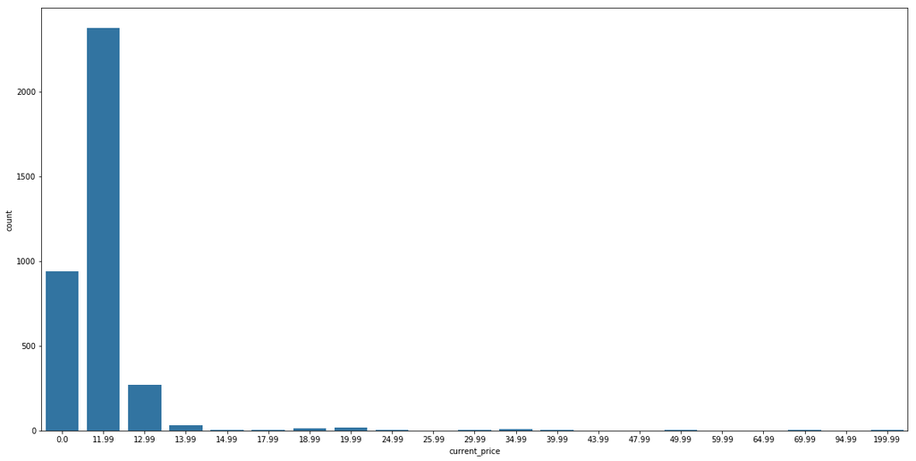

```python
sb.countplot( data=courses_data ,x='current_price',color = base_color)
fig = plt.gcf()
fig.set_size_inches(20, 10)
```

> we See now that all courses range from 0 to less than 25$$ and very few outliers can be found with values bigger than 25 $ lets remove outliers from the visualization

```python
courses_data= courses_data[courses_data["current_price"]<=25]
time_series = time_series[time_series["current_price"]<=25]
```

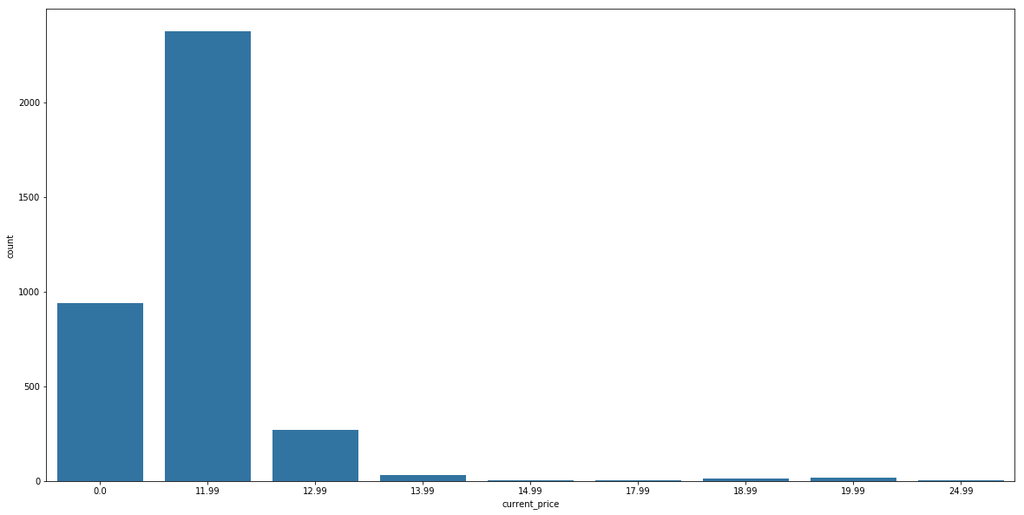

```python
sb.countplot( data=courses_data ,x='current_price',color = base_color)
fig = plt.gcf()
fig.set_size_inches(20, 10)
```

> after removing outliers we put more concentration on common prices

#### Checking num_lectures variable distribution

```python
print(courses_data.num_lectures.min(),courses_data.num_lectures.max())
```

```
0 670
```

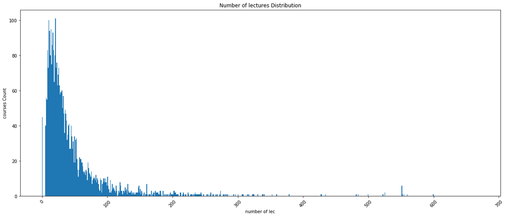

```python
# lets see courses price distribution
# Create bins with step-size
bins_step =1
bins = np.arange(0, courses_data.num_lectures.max(), bins_step)
plt.hist(data = courses_data, x = 'num_lectures', bins = bins)
plt.title('Number of lectures Distribution')
plt.xlabel('number of lec')
plt.ylabel('courses Count')
# # Change seaborn plot size
plt.xticks(rotation=45)
fig = plt.gcf()
fig.set_size_inches(20,8)
```

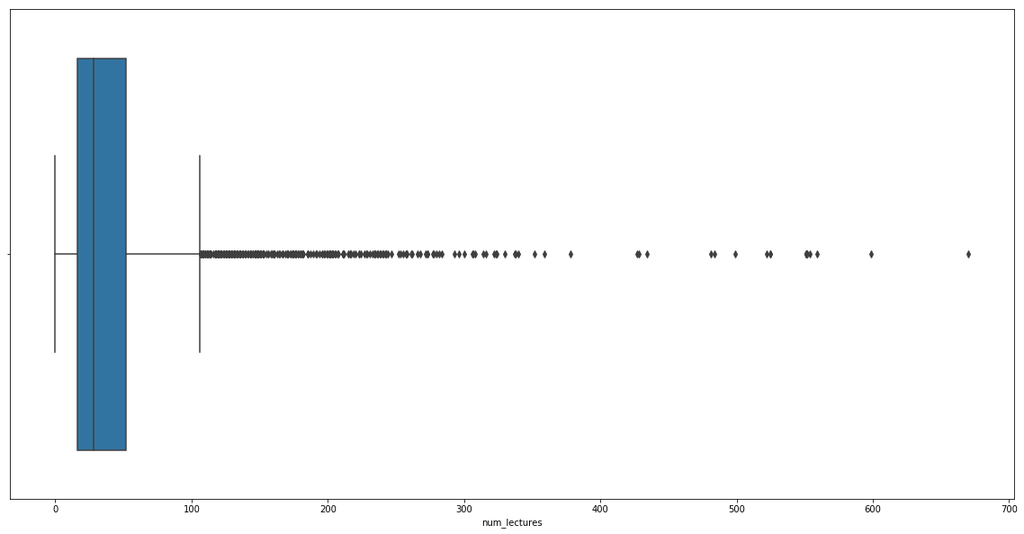

```python
plt.xlabel('number of lectures ')
fig = plt.gcf()
fig.set_size_inches(20, 10)
sb.boxplot(data=courses_data ,x='num_lectures')
```

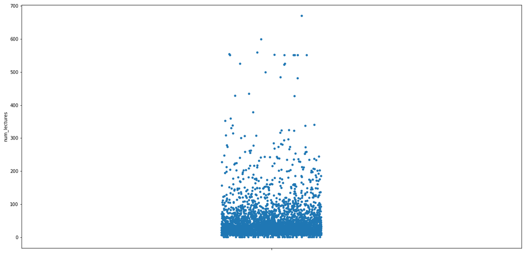

```python
sb.stripplot(y=courses_data['num_lectures'])
fig = plt.gcf()
fig.set_size_inches(20, 10)
```

> now now we can see that most of courses has range of 0 to 300 and some outliers so we we will remove the outliers

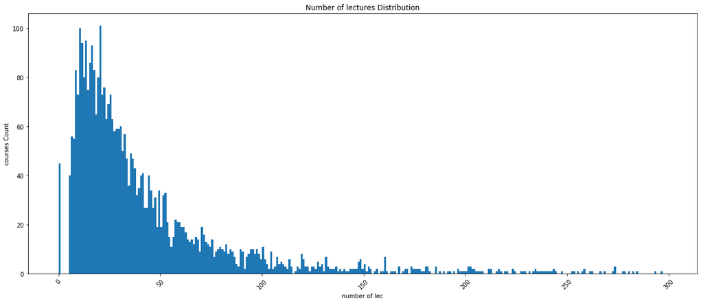

```python
# removing outliers
courses_data = courses_data[courses_data['num_lectures']<=300]
# lets see courses price distribution
# Create bins with step-size
bins_step =1
bins = np.arange(0, courses_data.num_lectures.max(), bins_step)
plt.hist(data = courses_data, x = 'num_lectures', bins = bins)
plt.title('Number of lectures Distribution')
plt.xlabel('number of lec')
plt.ylabel('courses Count')
# # Change seaborn plot size
plt.xticks(rotation=45)
fig = plt.gcf()
fig.set_size_inches(20,8)
```

#### Checking num_subscribers variable distribution

```python
courses_data.num_subscribers.value_counts().index.max()
```

```
1244120
```

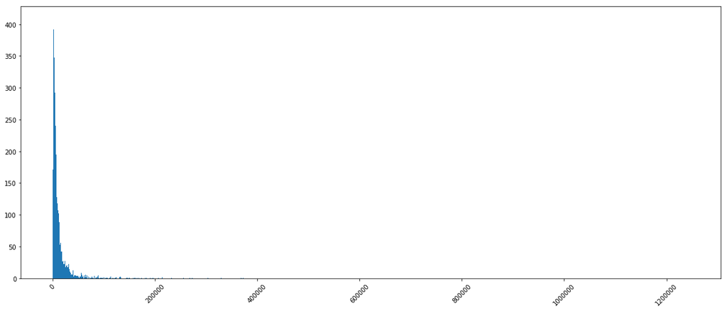

```python
bins_step =1000
bins = np.arange(0, courses_data.num_subscribers.max(), bins_step)
plt.hist(data = courses_data, x = 'num_subscribers', bins = bins)
# # Change seaborn plot size
plt.xticks(rotation=45)
fig = plt.gcf()
fig.set_size_inches(20, 8)
```

> most of courses has number of subscribers between 0 and 200k so outliers need to be removed

```python
courses_data = courses_data[courses_data['num_subscribers']<200000]
time_series = time_series[time_series['num_subscribers']<200000]
```

#### Checking primary_category variable distribution

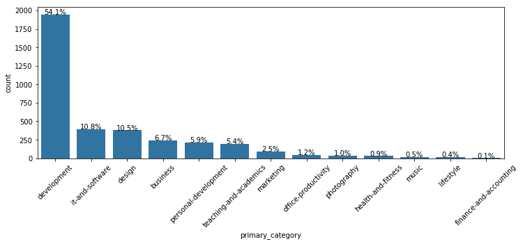

```python
Levels_count = courses_data['primary_category'].value_counts()
Levels_order = Levels_count.index

# Considering the same chart from the Example 1 above, print the text (proportion) BELOW the bars
base_color = sb.color_palette()[0]
sb.countplot(data=courses_data, x='primary_category', color=base_color, order=Levels_order);
df_count = courses_data.shape[0]
# Recalculating the type_counts just to have clarity.
type_counts = courses_data['primary_category'].value_counts()

# get the current tick locations and labels
locs, labels = plt.xticks(rotation=90)

# loop through each pair of locations and labels
for loc, label in zip(locs, labels):

    # get the text property for the label to get the correct count
    count = type_counts[label.get_text()]
    pct_string = '{:0.1f}%'.format(100*count/df_count)

    # print the annotation just below the top of the bar
    plt.text(loc, count+2, pct_string, ha = 'center', color = 'black')

plt.xticks(rotation=45)
fig = plt.gcf()
# Change seaborn plot size
fig.set_size_inches(12, 4)
```

> the category Distribution shows that this courses sample concentrates on development and softwware courses

#### Checking num of courses created over years

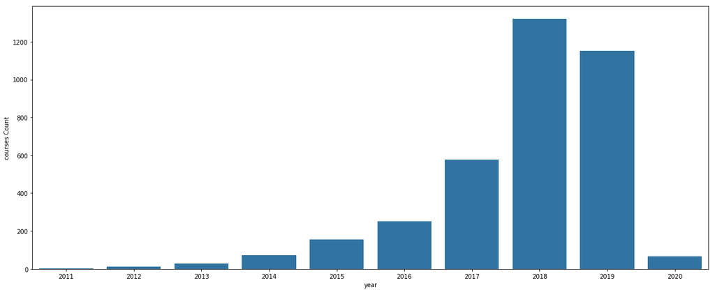

```python
sb.countplot(data = time_series, x = 'year', color = base_color)
# # Change seaborn plot size
plt.xlabel('year')
plt.ylabel('courses Count')
fig = plt.gcf()
fig.set_size_inches(20,8)
```

> Udemy, Inc. is an American massive open online course provider aimed at professional adults and students. It was founded in May 2010 so low numer of courses could be found for 2010 and 2011 on the other hand over years courses number grows very much and because this data is collected in the beginning of 2020 low number of courses created at 2020

#### Checking num of courses created over months

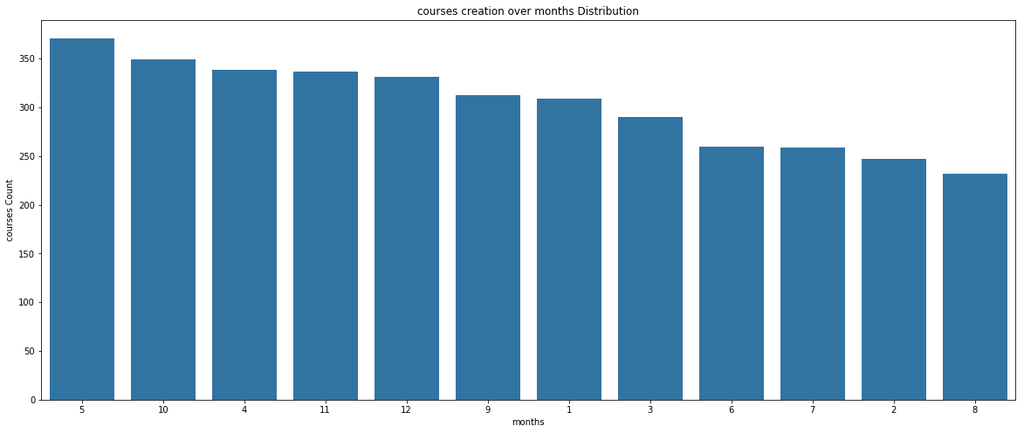

```python
sb.countplot(data = time_series, x = 'month', color = base_color ,order=time_series.month.value_counts().index)
plt.title('courses creation over months Distribution')
plt.xlabel('months')
plt.ylabel('courses Count')
fig = plt.gcf()
fig.set_size_inches(20,8)
```

> we can see that courses creation is the greatest in may

#### Checking course primary category distribution

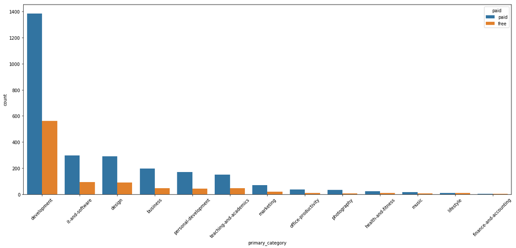

```python
sb.countplot(x="primary_category", hue="paid", data=courses_data ,order= courses_data.primary_category.value_counts().index)
fig = plt.gcf()
# Change seaborn plot size
fig.set_size_inches(20, 8)
plt.xticks(rotation=45)
```

> development and software are the most created courses as programming is one of the most important future jobs

### Discuss the distribution(s) of your variable(s) of interest. Were there any unusual points? Did you need to perform any transformations?

#### Of the features you investigated, were there any unusual distributions? Did you perform any operations on the data to tidy, adjust, or change the form of the data? If so, why did you do this?

i had to change course creation date to date time type to extract month and year of course creation i had to remove outliers from some of the columns mentioned above as num_subscribers and current_price

## Bivariate Exploration

> In this section, i will investigate relationships between pairs of variables in the data.

#### Checking relation between variables

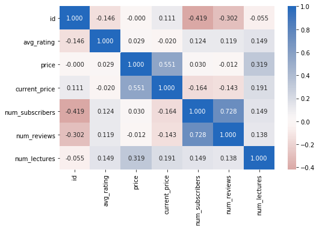

```python
plt.figure(figsize = [8, 5])
sb.heatmap(courses_data.corr(), annot = True, fmt = '.3f',cmap = 'vlag_r', center = 0)
plt.show()
```

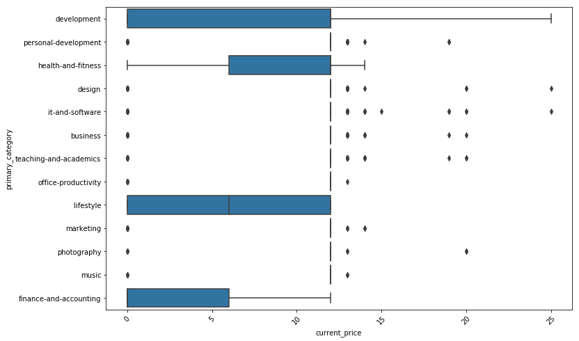

```python
sb.boxplot(x="current_price", y="primary_category", data=courses_data ,color = base_color )
# plt.yticks(np.arange(0, courses_data.current_price.max()+10,5));
plt.xticks(rotation=45)
fig = plt.gcf()
# Change seaborn plot size
fig.set_size_inches(12, 8)
```

> most of the courses price is between 0 and 15 dollar

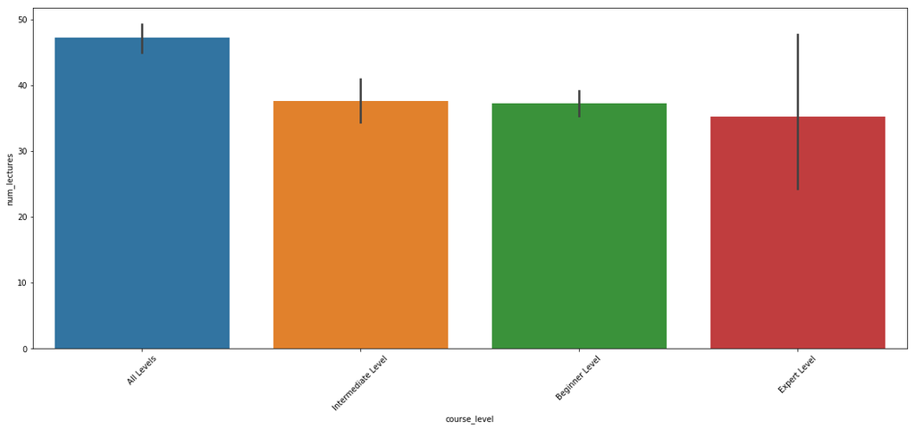

```python
sb.barplot(x="course_level", y="num_lectures", data=courses_data)
fig = plt.gcf()
# Change seaborn plot size
fig.set_size_inches(20, 8)
plt.xticks(rotation=45)
```

> experts rarely have time for courses so courses must be to the point and takes as less as possible from their time so we can see that expert courses has the smallest number of lectures

### Talk about some of the relationships you observed in this part of the investigation. How did the feature(s) of interest vary with other features in the dataset?

> there is a strong relation between number of subscribers and number of reviews as each courses subscriber can review course

> there is a relation between price and number of lectures as only paid courses can be longer than 2 hours

### Did you observe any interesting relationships between the other features (not the main feature(s) of interest)?

> no

## Multivariate Exploration

> lets see relations connects more than one variable

#### Check relation between course level ,number of subscibers and num_reviews

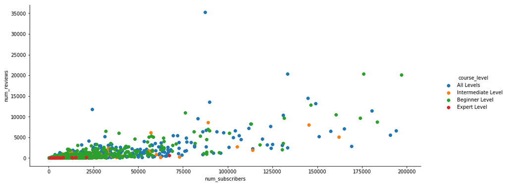

```python
g = sb.FacetGrid(data = courses_data, hue = 'course_level',size=10 )
g.map(plt.scatter, 'num_subscribers', 'num_reviews')
g.add_legend()
fig = plt.gcf()
fig.set_size_inches(15,5)
```

> as seen before number of expert level courses that is produced is small so expert level subscribers are few on the other hand courses for all and beginner levels has the most of the subscribers

#### Check relation between number of subscribers and average rating and courses price

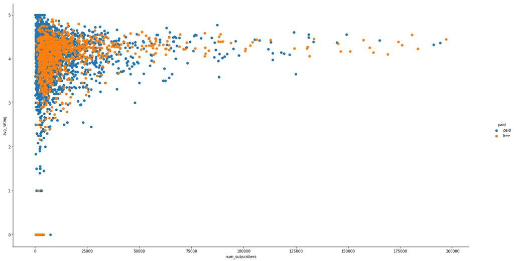

```python
g = sb.FacetGrid(data = courses_data, hue = 'paid',size=10 )
g.map(plt.scatter, 'num_subscribers', 'avg_rating')
g.add_legend()
fig = plt.gcf()
fig.set_size_inches(20,10)
```

### Talk about some of the relationships you observed in this part of the investigation. Were there features that strengthened each other in terms of looking at your feature(s) of interest?

> while investigation the relation between number of subscribers and course rate i realized that courses that have high rates attract customers more than free courses as there is many free courses have few little subscribers

### Were there any interesting or surprising interactions between features?

> no obvious surprising interaction could be mentioned